# Lab 05 - Data Wrangling

Phani Srija Kesara

September 24, 2024

# Source Data

The following analysis uses data comprised of traffic accidents in the city of Tempe, Arizona. They constitute 28,470 observations and 32 variables. You can find more details in the dataset documentation at the [**Tempe Open Data Portal**](https://data.tempe.gov/datasets/tempegov::1-08-crash-data-report-detail/about).

## Preview

We can explore the first six observations in the following table using function `head()`.

```r
head(dat)
```

|  | Incidentid | DateTime | Year | StreetName | CrossStreet | Distance | JunctionRelation | Totalinjuries | Totalfatalities | Injuryseverity | Collisionmanner | Lightcondition | Weather | SurfaceCondition | Unittype_One | Age_Drv1 | Gender_Drv1 | Traveldirection_One | Unitaction_One | Violation1_Drv1 | AlcoholUse_Drv1 | DrugUse_Drv1 | Unittype_Two | Age_Drv2 | Gender_Drv2 | Traveldirection_Two | Unitaction_Two | Violation1_Drv2 | AlcoholUse_Drv2 | … |
| --- | --- | --- | --- | --- | --- | --- | --- | --- | --- | --- | --- | --- | --- | --- | --- | --- | --- | --- | --- | --- | --- | --- | --- | --- | --- | --- | --- | --- | --- | --- |
| 1 | 2579417 | 1/10/12 9:04 | 2012 | Baseline Rd | Price Rd | -24.816 | Intersection Related Interchange | 0 | 0 | No Injury | Rear End | Daylight | Clear | Dry | Driver | 43 | Male | East | Going Straight Ahead | Inattention Distraction | No Apparent Influence | No Apparent Influence | Driver | 62 | Male | East | Going Straight Ahead | No Improper Action | No Apparent Influence | … |
| 2 | 2582044 | 1/5/12 17:24 | 2012 | Rural Rd | Playa Del Norte | -796.224 | Not Junction Related | 0 | 0 | No Injury | Rear End | Dusk | Clear | Dry | Driver | 19 | Male | North | Going Straight Ahead | Speed To Fast For Conditions | No Apparent Influence | No Apparent Influence | Driver | 28 | Male | North | Stopped In Trafficway | No Improper Action | No Apparent Influence | … |
| 3 | 2582996 | 1/16/12 19:08 | 2012 | Rio Salado Pkwy | State Route 101 Exit 51 J-Ramp | 0.000 | Intersection Interchange | 0 | 0 | No Injury | ANGLE (Front To Side)(Other Than Left Turn) | Dark Lighted | Clear | Dry | Driver | 26 | Male | North | Making Left Turn | Made Improper Turn | No Apparent Influence | No Apparent Influence | Driver | 24 | Male | West | Going Straight Ahead | No Improper Action | No Apparent Influence | … |
| 4 | 2584311 | 1/27/12 14:41 | 2012 | Rio Salado Pkwy | State Route 101 Exit 51 J-Ramp | 76.032 | Not Junction Related | 1 | 0 | Possible Injury | Rear End | Daylight | Cloudy | Dry | Driver | 29 | Male | West | Going Straight Ahead | Speed To Fast For Conditions | No Apparent Influence | No Apparent Influence | Driver | 18 | Female | West | Stopped In Trafficway | No Improper Action | No Apparent Influence | … |
| 5 | 2584437 | 1/10/12 13:41 | 2012 | Scottsdale Rd | State Route 202 Exit 7 P-Ramp | -40.128 | Entrance Exit Ramp Interchange | 0 | 0 | No Injury | Rear End | Daylight | Clear | Dry | Driver | 255 |  | North | Going Straight Ahead | Speed To Fast For Conditions | No Apparent Influence | No Apparent Influence | Driver | 26 | Male | North | Stopped In Trafficway | No Improper Action | No Apparent Influence | … |
| 6 | 2584439 | 1/9/12 17:49 | 2012 | Priest Dr | 12th St | 70.224 | Not Junction Related | 0 | 0 | No Injury | Sideswipe Same Direction | Dark Lighted | Clear | Unknown | Driver | 255 |  | Unknown | Unknown | Unknown | No Apparent Influence | No Apparent Influence | Driver | 31 | Female | South | Going Straight Ahead | No Improper Action | No Apparent Influence | … |

# Preprocessing

All data preprocessing are available in **Appendix A: Data Preprocessing**.

# Part I: Summaries

The following provides brief exploratory summaries on key data points.

## 1. Mondays Accidents

**Question:** *How many accidents happened on Mondays?*

**Note:** *This solution has been completed for you.*

```r
sum(dat$day == "Mon",
    na.rm = TRUE)
```

```
## [1] 4094
```

**Answer:** **4,094** accidents occurred on Mondays.

## 2. Monday Accidents (%)

**Question:** *What proportion of accidents each week occur on Monday?*

```r
total_accidents <- nrow(dat)

monday_accidents <- sum(dat$day == "Mon", na.rm = TRUE)

monday_proportion <- monday_accidents / total_accidents*100
```

**Answer:** **14.38%** of all accidents occur on Mondays.

## 3. Harmful Monday Accidents (%)

**Question:** *What proportion of accidents on Mondays result in harm?*

**Note:** *“Harm” is defined as any accident that causes at least one injury or* *fatality, a.k.a. a “casualty”.*

```r
harmful_monday_accidents <- sum(dat$day == "Mon" & (dat$Totalinjuries > 0 | dat$Totalfatalities > 0), na.rm = TRUE)

harmful_monday_proportion <- harmful_monday_accidents / monday_accidents*100
```

**Answer:** **29.848%** of all Monday accidents have at least one casualty.

## 4. Most Common Accidents

**Question:** *What is the most common type of accident (Collisionmanner) that occurs on Mondays?*

```r
dat %>%
  filter(day == "Mon") %>%
  count(Collisionmanner) %>%
  arrange(desc(n))
```

| Collisionmanner | n |
| --- | --- |
| Rear End | 1566 |
| Left Turn | 733 |
| ANGLE (Front To Side)(Other Than Left Turn) | 707 |
| Sideswipe Same Direction | 535 |
| Single Vehicle | 225 |
| Other | 171 |
| Unknown | 47 |
| Head On | 44 |
| Rear To Side | 29 |
| Sideswipe Opposite Direction | 29 |

[output cut: 1 more lines]

**Answer:** **Rear End** collisions are the most common accident types.

## 5. Differences in Accidents

**Question:** *Are there differences in the proportion of accidents that result in harm each day of the week?*

```r
dat %>%
  group_by(day) %>%
  summarize(harmful_accidents = sum(Totalinjuries > 0 | Totalfatalities > 0),
            total_accidents = n(),
            harm_rate = harmful_accidents / total_accidents)
```

| day | harmful_accidents | total_accidents | harm_rate |
| --- | --- | --- | --- |
| Mon | 1222 | 4094 | 0.2984856 |
| Tue | 1503 | 4656 | 0.3228093 |
| Wed | 1483 | 4711 | 0.3147952 |
| Thu | 1574 | 4814 | 0.3269630 |
| Fri | 1481 | 5006 | 0.2958450 |
| Sat | 805 | 3044 | 0.2644547 |
| Sun | 576 | 2145 | 0.2685315 |

## 6. Accident Stats by Weekday

**Instructions:** Create a table that reports the following for each day of the week.

- Total accidents
- Total injuries
- Total fatalities
- Proportion of harmful accidents (i.e. casualties)

```r
dat %>%
  group_by(day) %>%
  mutate(harm_acc = Totalinjuries > 0 | Totalfatalities > 0) %>%
  summarize(n = n(),
            injuries = sum(Totalinjuries),
            fatalities = sum(Totalfatalities),
            harm.rate = mean(harm_acc))
```

| day | n | injuries | fatalities | harm.rate |
| --- | --- | --- | --- | --- |
| Mon | 4094 | 1644 | 13 | 0.2984856 |
| Tue | 4656 | 2056 | 8 | 0.3228093 |
| Wed | 4711 | 2144 | 9 | 0.3147952 |
| Thu | 4814 | 2204 | 10 | 0.3269630 |
| Fri | 5006 | 2103 | 12 | 0.2958450 |
| Sat | 3044 | 1192 | 11 | 0.2644547 |
| Sun | 2145 | 866 | 6 | 0.2685315 |

# Part II: Age Groups

The following provides summaries of accidents by age groups.

## 1. Accidents by Hour & Age

**Instructions:** Create a table of counts of accidents by time of day (`hour12`) and age of driver (`age`).

**Question:** *Which age group has the largest number of accidents at 7AM?*

```r
# Count accidents by hour and age group, excluding NA ages
accidents_by_hour_age <- dat %>%
  filter(hour12 == "7 AM", !is.na(age)) %>%
  group_by(age) %>%
  summarize(count = n()) %>%
  arrange(desc(count))

# Display the result
accidents_by_hour_age
```

[output not shown]

**Answer:** Drivers of **18-25** have the greatest number of accidents from 7:00 to 7:59 AM.

## 2. Accidents by Hour & Age (%)

**Instructions:** Create a new table of time of day and age group that reports the proportion of accidents at “7 AM” (`hour12`) for each age group (`age`). *The proportions within each age group should sum to one.*

**Objective:** The table should contain the following columns and initial values:

| age | hour12 | n | n.age | n.hour | p | p.age | p.hour |
| --- | --- | --- | --- | --- | --- | --- | --- |
| Age 16-18 | 7 AM | 77 | 1458 | 1606 | 0.05 | 0.05 | 0.05 |
| Age 18-25 | 7 AM | 408 | 8796 | 1606 | 0.25 | 0.05 | 0.25 |
| Age 25-35 | 7 AM | 371 | 5456 | 1606 | 0.23 | 0.07 | 0.23 |

**Solution:** *The solution has been partially provided. Use the hints provided to create the table.*

```r
# Calculate total accidents for each age group
total_accidents_by_age <- dat %>%
  filter(!is.na(age)) %>%
  group_by(age) %>%
  summarize(total_accidents = n())

# Calculate proportion of accidents at 7 AM for each age group
proportion_by_age <- dat %>%
  filter(hour12 == "7 AM", !is.na(age)) %>%
  group_by(age) %>%
  summarize(accidents_at_7am = n()) %>%
  left_join(total_accidents_by_age, by = "age") %>%
  mutate(proportion = accidents_at_7am / total_accidents) %>%
  arrange(desc(proportion))

# Display the result
proportion_by_age
```

[output not shown]

# Part III: Rates of Harm

The following reports the accidents, casualties, proportion, and average casualties per harmful accident.

## 1. Accidents by Hour

**Instructions:** Visualize total accidents by time of day (`hour`).

**Note:** *This solution has been completed for you.*

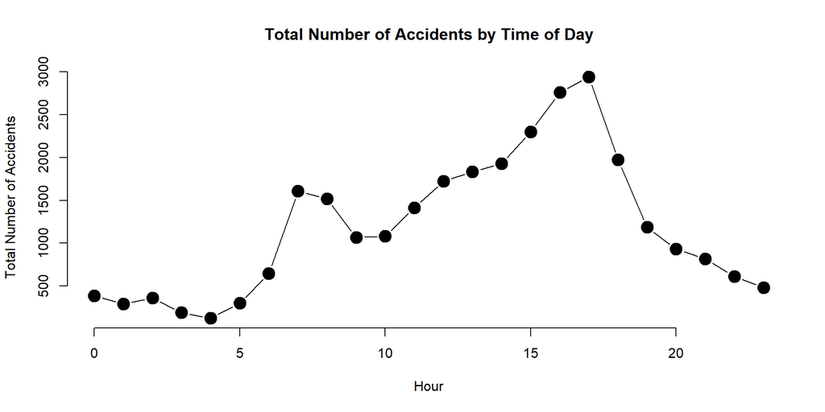

```r
dat %>%
  group_by(hour) %>%
  summarize(n = n()) %>%
  plot(type = "b",
       bty = "n",
       pch = 19,
       cex = 2,
       xlab = "Hour",
       ylab = "Total Number of Accidents",
       main = "Total Number of Accidents by Time of Day")
```

## 2. Total Casualties by Hour

**Instructions:** Visualize total injuries and fatalities by time of day (`hour`).

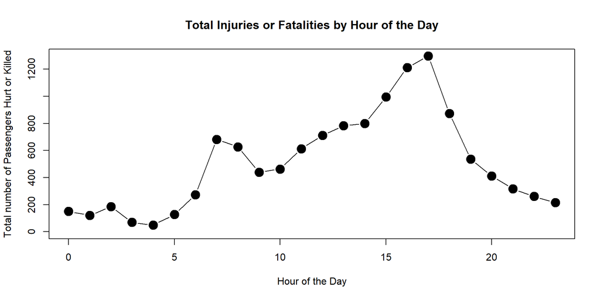

```r
# Summarizing total injuries and fatalities by hour
casualties_by_hour <- dat %>%
  group_by(hour) %>%
  summarize(total_injuries = sum(Totalinjuries, na.rm = TRUE),
            total_fatalities = sum(Totalfatalities, na.rm = TRUE))

# Convert hour to numeric
casualties_by_hour$hour <- as.numeric(as.character(casualties_by_hour$hour))

# Plotting total injuries and fatalities
plot(casualties_by_hour$hour,
     casualties_by_hour$total_injuries,
     type = "b",
     pch = 19,
     cex = 2,
     ylim = c(0, max(casualties_by_hour$total_injuries, casualties_by_hour$total_fatalities)),
     xlab = "Hour of the Day",
     ylab = "Total number of Passengers Hurt or Killed",
     main = "Total Injuries or Fatalities by Hour of the Day")
```

## 3. Accidents with Casualties (%)

**Instructions:** Visualize the proportion of harmful accidents out of all accidents by time of day (`hour`).

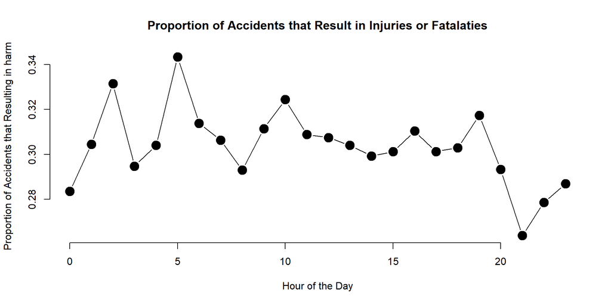

```r
# Calculate the proportion of harmful accidents by hour
harmful_accidents <- dat %>%
  group_by(hour) %>%
  summarize(total_accidents = n(),
            harmful_accidents = sum(Totalinjuries > 0 | Totalfatalities > 0)) %>%
  mutate(proportion_harmful = harmful_accidents / total_accidents)

# Plot the proportion of harmful accidents
plot(harmful_accidents$hour, harmful_accidents$proportion_harmful,
     pch = 19, type = "b", cex = 2, bty = "n",
     xlab = "Hour of the Day",
     ylab = "Proportion of Accidents that Resulting in harm",
     main = "Proportion of Accidents that Result in Injuries or Fatalaties")
```

## 4. Avg. Harm by Harmful Accident

**Instructions:** Visualize average injuries or fatalities per harmful collision.

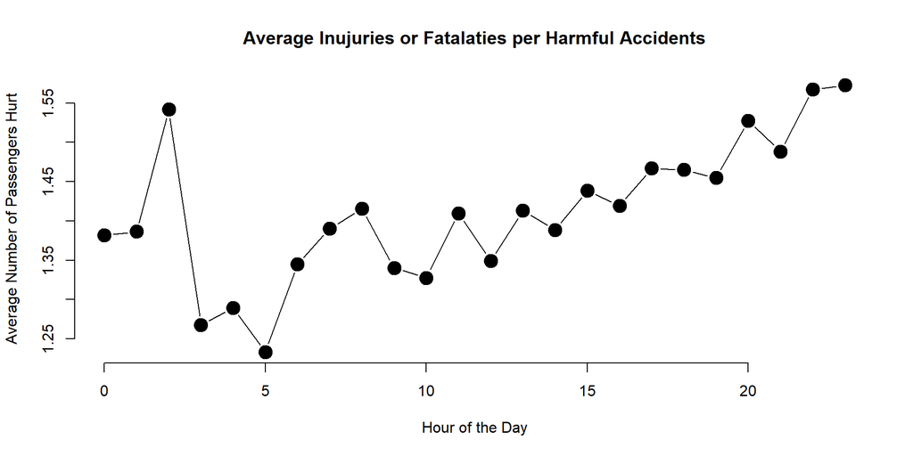

```r
# Calculate aver injuries or fatalities per harmful collision by hour
aver_harm <- dat %>%
  group_by(hour) %>%
  summarize(total_harmful = sum(Totalinjuries > 0 | Totalfatalities > 0),
            total_injuries = sum(Totalinjuries),
            total_fatalities = sum(Totalfatalities)) %>%
  mutate(aver_harm = (total_injuries + total_fatalities) / total_harmful)

# Plot aver injuries or fatalities per harmful collision
plot(aver_harm$hour, aver_harm$aver_harm,
     pch = 19, type = "b", cex = 2, bty = "n",
     xlab = "Hour of the Day",
     ylab = "Average Number of Passengers Hurt",
     main = "Average Inujuries or Fatalaties per Harmful Accidents")
```

# Appendix

The following code is used for preprocessing tasks in the above solutions.

## A: Data Preprocessing

These expressions transform, format, and create myriad new variables used in this report.

```r
date.vec <- strptime(dat$DateTime,
                     format = "%m/%d/%y %H:%M")       # Create date fields

dat$hour   <- format(date.vec, format = "%H")
dat$month  <- format(date.vec, format = "%b")
dat$day    <- format(date.vec, format = "%a")
dat$day365 <- format(date.vec, format = "%j")
dat$week   <- format(date.vec, format = "%V")

dat$day <- factor(dat$day,
                  levels = c("Mon",
                             "Tue",
                             "Wed",
                             "Thu",
                             "Fri",
                             "Sat",
                             "Sun"))                  # Order weekdays

dat$hour12 <- format(date.vec,
                     format="%l %p")                  # Create 12-hour format

time.levels <- c("12 AM", paste(1:11, "AM"),
                 "12 PM", paste(1:11, "PM"))

dat$hour12 <- factor(dat$hour12,
                     levels = time.levels)            # Order time intervals

age.labels <- paste0("Age ",
                     c(16,18,25,35,45,55,65,75), "-",
                     c(18,25,35,45,55,65,75,100) )

dat$age <- cut(dat$Age_Drv1,
               breaks = c(16,18,25,
                          35,45,55,
                          65,75,100),
               labels = age.labels)                   # Discretize age ranges
```